# FlightsOverYear_Yankee

Tyler Yankee

9/27/2022

## Load data and relevant packages

```r
library(tidyverse)
library(here)
library(janitor)
df2017 = read_csv(here("data_raw/airline_data", "airline_data_2017.zip")) %>% clean_names()
df2018 = read_csv(here("data_raw/airline_data", "airline_data_2018.zip")) %>% clean_names()
df2019 = read_csv(here("data_raw/airline_data", "airline_data_2019.zip")) %>% clean_names()
df2020 = read_csv(here("data_raw/airline_data", "airline_data_2020.zip")) %>% clean_names()
df2021 = read_csv(here("data_raw/airline_data", "airline_data_2021.zip")) %>% clean_names()
df2022 = read_csv(here("data_raw/airline_data", "airline_data_2022.zip")) %>% clean_names()
# Make a list of these dataframes so that we can iterate through them later
# Indexing - 1=2017, 2=2018, 3=2019, 4=2020, 5=2021, 6=2022
years_list = list(df2017, df2018, df2019, df2020, df2021, df2022)
```

## Break down each year by month and look at flights for Southwest Airlines.

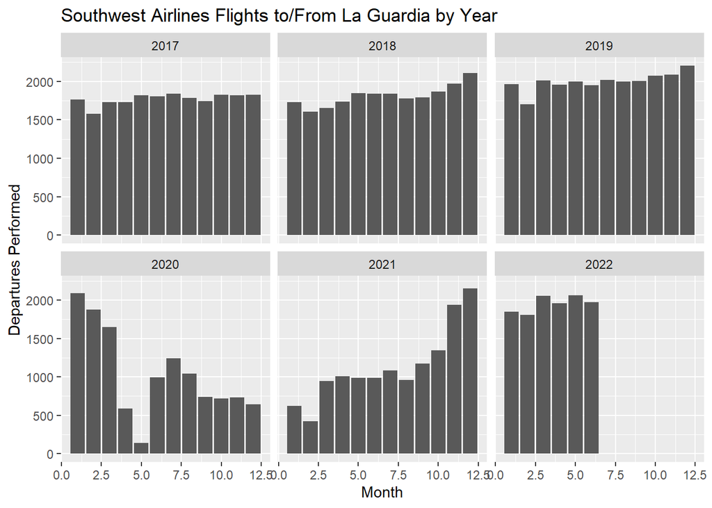

```r
df_complete = rbind(df2017,df2018,df2019,df2020,df2021,df2022) %>%
  filter(origin == "LGA" | dest == "LGA", carrier_name == "Southwest Airlines Co.",
         passengers > 0) %>%
  select(departures_performed, passengers, carrier_name, origin, dest, year, month) %>%
  mutate(total_month = month + 12*(year - 2017))
df_complete %>% ggplot(aes(x = month)) + geom_bar(aes(weight = departures_performed)) +
  facet_wrap(~year) + labs(title = "Southwest Airlines Flights to/From La Guardia by Year",
                           x = "Month", y = "Departures Performed")
```

## Discussion of possibilities for visualizations

Assume to and from LGA.

- passengers over time for the total 6 years - get a time column, month * (year - 2017)
- could break this up by flight, by destination, etc.
- choose other airports and see if pattern is the same for your given airport - facet?
- Is your airline like the other airlines?

## New visualization

The new complete dataframe combines each year of data; filters to LaGuardia, Southwest Airlines, and flights with passengers; and adds a new column representing the total month since 2017.

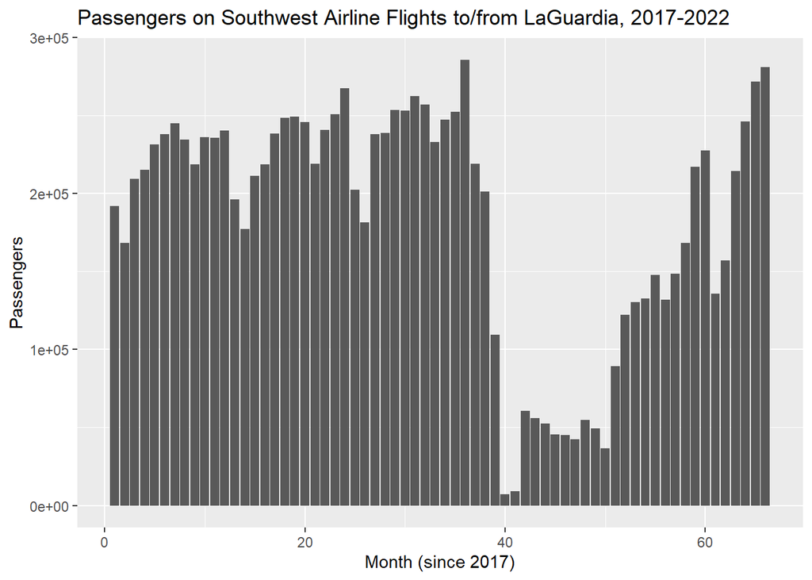

```r
df_complete %>% ggplot(aes(x = total_month)) +
  geom_bar(aes(weight = passengers)) +
  ggtitle("Passengers on Southwest Airline Flights to/from LaGuardia, 2017-2022") +
  xlab("Month (since 2017)") + ylab("Passengers")
```

Some thoughts on the above graph…

- The end of 2019 saw a particularly high number of passengers. The end of each year was high in general, but even given that it is high compared to the ends of other years.
- The abrupt drop in March 2020 due to the COVID shutdown is made painstakingly clear here, especially because we filtered for only flights with some passengers (so no cargo-only flights etc.).
- In general, the pattern year-over-year remains roughly the same - not counting the time during the pandemic.
- It seems that passenger levels could be returning to pre-pandemic levels. Would be interested to see the summer 2022 data (this only goes up to June).